# NYC HIV/AIDS Diagnoses by Neighborhood, Sex, and Race/Ethnicity

This vignette will cover the XML file type and XML R package, using NYC HIV/AIDS diagnosis data as an example dataset.

# XML and the XML package

XML, short for Extensible Markup Language, is a markup language which defines a set of rules to encode documents that is both human-readable and machine readable. It is an open standard, published in 1998, designed to structure documents as a response to the development of the internet.

## XML

It is used all over the place, particularly 10-15 years ago. XML is used to store and/or transport data frequently on websites. It acts like a minimal HTML, with no attributes to determine color or size for instance. It’s frequently used under the covers. For example, it is the standard for Microsoft Office file formats and Google Docs. Change the extension from .docx to .xml, and you’ll be able to edit your word docs as an XML file. More info on XML files [here](https://www.makeuseof.com/tag/xml-file-case-wondering/)

XML is made up of unicode characters and involves tags and content. The focus was on making XML as flexible as possible to deliver data. As such, there are no predefined tags (compare that to HTML for example). Basically, it is a collection of tags, surrounded by `<` and `>`, and content. As described by [W3 Schools](https://www.w3schools.com/xml/xml_whatis.asp), the following are the primary components:

- An attribute consists of a name, value pair within a start tag or an empty element tag. For example: `<img src="turtle.jpg"/>`
- Content is the stuff between the opening and closing tag.
- An element consists of the opening tag, its attributes, any content, and a closing tag.
- A tag, the aforementioned item surrounded by a `<` and `>`, is used to mark the start or end of an element. When used to mark the end of an element, it begins with `</`.
- A node is a part of the hierarchical structure that makes up an XML document. Node is a generic term that applies to any type of XML object, including elements, attributes, comments, processing instructions, and plain text.
- An example of a complete element: `<statement>I like turtles</statement>`

## XML package in R

The `XML` package in R is one of two popular packages used for reading in XML. The other one is `xml2`. `XML` is the original R package for parsing XML documents. It is no longer actively maintained, but stable and still very popular. `xml2` is the new package on the block. It is actively maintained and more recently developed in response to the former’s weaknesses. I opted for using `XML` in lieu of `xml2` because most of the code I found online was still using it, which is a good sign. Furthermore, my XML file was not particularly complex, requiring less of the additional features found in `xml2`. One interesting nugget is that someone has gone through the hard work of translating `XML` to `xml2` code. Read more [here](https://gist.github.com/nuest/3ed3b0057713eb4f4d75d11bb62f2d66) if you need to make the conversion.

- `file`: name of the file, URL, or XML content itself
- `options`: a list of different specified options which are entered as elements of an integer vector which are bitwise ORed together.
- `encoding`: used to specify the encoding of the document if not explicitly contained in the document itself.
- `asText`: used to specify if the file is the XML content or the name of a file/URL (FALSE)
- `baseURL`: used to resolve relative documents if the XML file links to others.

```r
doc <- xmlParseDoc("Data/hiv.xml")
```

The other function which I am using from the `XML` package is `xmlToDataFrame`. This function has the following arguments:

- `doc`: specifies the XML content. This can be a parsed XML or a file location.
- `colClasses`: list giving the names of the R types for corresponding variables and used to coerce the column in the dataframe result to this type.
- `homogenous`: a logical value to let the function know if the nodes contains all the variables or if there are some nodes which only contain a subset. The function will interpret this if it isn’t specified.
- `collectNames`: Determines if one should union all variable names or if you use the names from the node with the greatest number of children.
- `nodes`: A list of XML nodes to be processed. Useful in this case since we need to go down a couple levels before we get to a simple record list to read into a dataframe.
- `stringsAsFactors`: should character vectors be converted to factor objects in the resulting dataframe?

Finally, I use the `getNodeSet` function to specify which nodes should be converted to a dataframe. This function extracts the desired nodes before piping it into the conversion. The two arguments which I required were: * `doc`: an object of class XMLInternalDocument. * `path`: a string giving the XPath expression to evaluate. Here, I’m saying open the response node, open the row node, then select all child nodes.

```r
hiv <- xmlToDataFrame(doc, nodes=getNodeSet(doc, "/response/row/*"), stringsAsFactors = FALSE)
```

# NYC HIV dataset

## Input and Cleaning

```r
# Simple data cleaning function to automatically figure out which fields need replacing of the * value and calc pop estimate
cleanData<- function(df) {
  # Replace * with NA for future analysis
  flagColList<-grep("num", names(df), value=TRUE)
  for (flagCol in flagColList) {
    df[[flagCol]][df[[flagCol]] == '*']<- NaN
    df[[flagCol]][df[[flagCol]] == 'NA']<- NaN
    df[[flagCol]][is.na(df[[flagCol]])]<- NaN
    df[[flagCol]] <- as.numeric(df[[flagCol]])
  }

  return(df)
}

# A function to aid in the later mutate function which calculates an estimated population size when possible to do so
estimator<- function(hivn, hivper100) {
  if ((!is.na(hivper100) & ! is.na(hivn)) & ((hivper100 > 0) & (hivn > 0))) {
    total <- hivn/ (hivper100 / 100000)
  } else {
    total <- NaN
  }
  return(total)
}

hiv<- cleanData(hiv) %>% rowwise() %>% mutate(estimated_population = estimator(hivn=hiv_diagnoses_num, hivper100=hiv_diagnoses_num_per_100k)) %>% as.data.frame()

head(hiv)
```

|  | year | neighborhood | sex | race | hiv_diagnoses_num | hiv_diagnoses_num_per_100k | hiv_aids_concurrent_num | concurrent_hiv_aids_among_all | aids_diagnoses_num | aids_diagnoses_num_per_100k | estimated_population |
| --- | --- | --- | --- | --- | --- | --- | --- | --- | --- | --- | --- |
| 1 | 2013 | Port Richmond | Female | Native American | 0 | 0.0 | 0 | 0 | 0 | 0.0 | NaN |
| 2 | 2013 | Kingsbridge - Riverdale | Female | Unknown | 0 | 0.0 | 0 | 0 | 0 | 0.0 | NaN |
| 3 | 2013 | Stapleton - St. George | Female | All | 5 | 7.7 | 3 | 60 | 4 | 6.2 | 64935.06 |
| 4 | 2013 | Gramercy Park - Murray Hill | Female | All | 3 | 4.1 | 0 | 0 | 0 | 0.0 | 73170.73 |
| 5 | 2013 | Pelham - Throgs Neck | Male | Black | 24 | 84.1 | 4 | 16.7 | 23 | 80.6 | 28537.46 |
| 6 | 2013 | Lower Manhattan | Male | Multiracial | 0 | 0.0 | 0 | 0 | 0 | 0.0 | NaN |

## EDA

```r
hiv  %>% filter(!is.na(hiv_diagnoses_num)) %>% select(year, sex, hiv_diagnoses_num)%>% group_by(year, sex) %>% summarize(hiv_diagnoses= sum(hiv_diagnoses_num)) %>% spread(year, hiv_diagnoses) %>% kable()
```

| sex | 2010 | 2011 | 2012 | 2013 |
| --- | --- | --- | --- | --- |
| All | 6706 | 6450 | 5980 | 5664 |
| Female | 1503 | 1438 | 1246 | 1103 |
| Male | 5201 | 5010 | 4732 | 4557 |

**Figure 1:** A contingency table for sex and year with values being for HIV diagnosis totals. It isn’t clear what the takeaway is here. It may be a dead end.

```r
hiv  %>% filter(!is.na(hiv_diagnoses_num)) %>% select(race, sex, hiv_diagnoses_num) %>% group_by(race, sex) %>% summarize(hiv_diagnoses= sum(hiv_diagnoses_num)) %>% spread(race, hiv_diagnoses) %>% kable()
```

| sex | All | Asian/Pacific Islander | Black | Hispanic | Multiracial | Native American | Unknown | White |
| --- | --- | --- | --- | --- | --- | --- | --- | --- |
| All | 24800 | NA | NA | NA | NA | NA | NA | NA |
| Female | 2646 | 42 | 1662 | 751 | 17 | 0 | 0 | 172 |
| Male | 9754 | 371 | 3886 | 3268 | 61 | 4 | 0 | 2156 |

**Figure 2:** A contingency table for race and sex totals. Here, we definitely see a discrepancy. Native Americans are not well represented due to such a small population size in NYC to begin with, but males are the vast majority of cases for all racial groups.

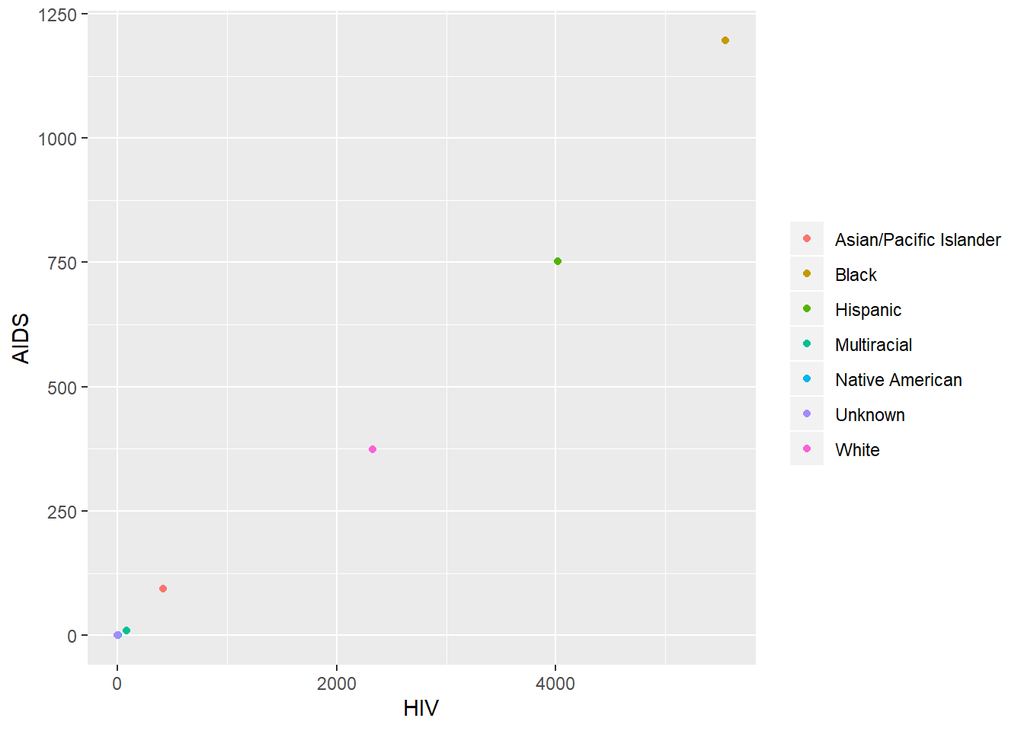

```r
hivS<- hiv %>% filter(!is.na(hiv_diagnoses_num) & !is.na(hiv_aids_concurrent_num) & (race != 'All')) %>% group_by(race) %>% summarize(HIV=sum(hiv_diagnoses_num), AIDS=sum(hiv_aids_concurrent_num))

ggplot(data=hivS, aes(x=HIV, y=AIDS)) + geom_point(aes(color=factor(race))) +  theme(legend.title = element_blank())
```

**Figure 3:** Here we have a plot of AIDS prevalence vs. HIV prevalence. As one might expect, there is a linear relationship between the two (HIV slowly develops into AIDS if not treated). The colors represent racial demographic.

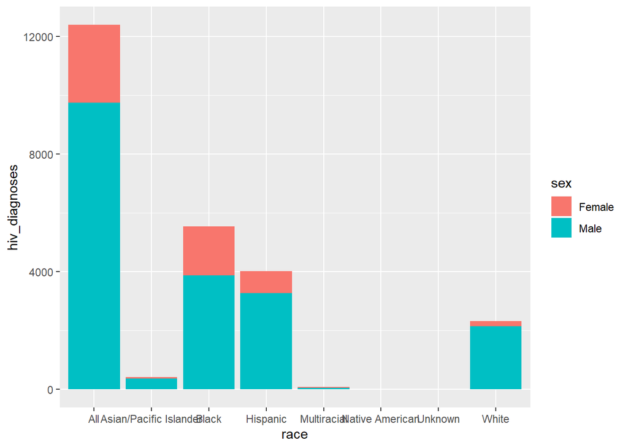

```r
b1<- hiv  %>% filter(!is.na(hiv_diagnoses_num) & sex != 'All') %>% select(race, sex, hiv_diagnoses_num) %>% group_by(race, sex) %>% summarize(hiv_diagnoses= sum(hiv_diagnoses_num))

ggplot(b1, aes(fill=sex, y=hiv_diagnoses, x=race)) + geom_bar(position="stack", stat = 'identity')
```